# Unstructured Project

Author

Jill Stafford

# Introduction

Project description: Looking at the differences between global Catholic populations from 1910 to 2010, I want to understand what may have caused or contributed to these changes in the rising and falling of numbers.

Index: -Scraping Images -Optical Character Recognition (OCR) -Population Growth Factor Calculations -Topic Modeling (3 types) -Sentiment Analysis (2 types) -Regex Content Extraction -Conclusion

# Image Scraping

Here I scraped Catholic Population images from pew research that contained statistics from 1910 and 2010(it was a very tough process of trial and error.)

```python
import requests
from bs4 import BeautifulSoup
from urllib.parse import urljoin
import os

chart_pages = [
    "https://www.pewresearch.org/religion/2013/02/13/the-global-catholic-population/pf_13-02-13_global-catholics_chart-3/",
    "https://www.pewresearch.org/religion/2013/02/13/the-global-catholic-population/pf_13-02-13_global-catholics_chart-4/"
]

headers = {"User-Agent": "Mozilla/5.0"}
os.makedirs("charts", exist_ok=True)

chart_imgs = []

for page in chart_pages:
    r = requests.get(page, headers=headers)
    soup = BeautifulSoup(r.text, "html.parser")

    img = soup.find("img")
    if not img:
        print("[!] No image found on:", page)
        continue

    src = img.get("src")
    if src:
        full = urljoin(page, src)
        chart_imgs.append(full)

print("[+] Found chart images:")
for c in chart_imgs:
    print("   ", c)

for i, img_url in enumerate(chart_imgs, start=1):

    clean_url = img_url.split("?")[0]

    img_data = requests.get(clean_url, headers=headers).content
    ext = os.path.splitext(clean_url)[1]
    filename = f"charts/chart_{i}{ext}"

    with open(filename, "wb") as f:
        f.write(img_data)

    print("[✓] Saved:", filename)
```

```
[+] Found chart images:
    https://www.pewresearch.org/wp-content/uploads/sites/20/2013/02/PF_13.02.13_Global-Catholics_chart-3-1.png?w=560
    https://www.pewresearch.org/wp-content/uploads/sites/20/2013/02/PF_13.02.13_Global-Catholics_chart-4-1.png?w=560
[✓] Saved: charts/chart_1.png
[✓] Saved: charts/chart_2.png
```

Here I displayed the images I extracted to make sure that the scraping worked.

[figure not shown]

[figure not shown]

```python
from IPython.display import Image, display

display(Image(filename="charts/chart_1.png"))
display(Image(filename="charts/chart_2.png"))
```

# Optical Character Recognition (OCR)

I downloaded Tesseract to do OCR and scrape the statistical information from the images

```python
import pytesseract
from PIL import Image
import re
import pandas as pd

pytesseract.pytesseract.tesseract_cmd = r"C:\Program Files\Tesseract-OCR\tesseract.exe"
print(pytesseract.get_tesseract_version())
```

```
5.5.0.20241111
```

Here I printed the scraped data from one of the images to confirm it worked before the next step.

```python
img = Image.open("charts/chart_2.png")
text = pytesseract.image_to_string(img, config="--psm 6")
print(text)
```

```
10 Countries with the Largest Number of Catholics, 1910

France 40,510,000 08.4% 13.0%
italy .35,270,000 90.0 at
Brazil 21,430,000 056 14
Spain 20,360,000 90.0 10
Poland 18,750,000 aay 64
Germany 16,580,000 387 87
Mexico 114,280,000 o10 49
United States 12,470,000 142 43
Philippines 7,260,000 78.1 25
Czech Republic 7,420,000 862 24
World Total 291,290,000 166 100.0
Fue for 1910 ate from the Word Christian Databaes (Er2013). Population estimate ate oundedtothetan thousands

percentages ar calculated fom unvunded numbers. Fgwes ay rot edd excl duet rounding

Pew Research Onter
```

Here I ran OCR again, created an empty table, looped through the extracted text of data lines, checked if a line contained a population number, extracted the info from the line, appended the extracted row, and then returned the dataframe.

```python
def extract_table_from_chart(path, year):
    img = Image.open(path)

    raw = pytesseract.image_to_string(img, config="--psm 6")

    rows = []

    for line in raw.splitlines():
        line = line.strip()
        if not line:
            continue

        skip_fragments = [
            "10 Countries", "Countries", "ESTIMATED", "PERCENTAGE",
            "World Total", "Population estimates", "Figures for 1910",
            "Pew Research"
        ]
        if any(s.lower() in line.lower() for s in skip_fragments):
            continue

        if not re.search(r"\d[\d,]*,\d{3},\d{3}", line) and not re.search(r"\.\d[\d,]*,\d{3},\d{3}", line):
            continue

        m_country = re.match(r"^[A-Za-z .]+", line)
        if not m_country:
            continue
        country = m_country.group(0).strip().title()

        m_pop = re.search(r"\.?\d[\d,]*,\d{3},\d{3}", line)
        if not m_pop:
            continue
        pop_str = m_pop.group(0).replace(".", "")
        pop = int(pop_str.replace(",", ""))

        rest = line[m_pop.end():]

        nums = re.findall(r"[\d\.]+", rest)

        pct_cat = None
        pct_world = None
        if len(nums) >= 2:
            pct_cat = float(nums[-2])
            pct_world = float(nums[-1])

        rows.append({
            "Country": country,
            "Year": year,
            "Catholic_Pop": pop,
            "Percent_Catholic": pct_cat,
            "Percent_World_Catholics": pct_world
        })

    return pd.DataFrame(rows)
```

Here I printed the charts, but they got mixed up.

```python
df_1910 = extract_table_from_chart("charts/chart_1.png", 1910)
df_2010 = extract_table_from_chart("charts/chart_2.png", 2010)

print("1910:")
display(df_1910)

print("2010:")
display(df_2010)
```

```
1910:
```

|  | Country | Year | Catholic_Pop | Percent_Catholic | Percent_World_Catholics |
| --- | --- | --- | --- | --- | --- |
| 0 | Brazil | 1910 | 126750000 | 65.0 | 11.7 |
| 1 | Mexico | 1910 | 96450000 | 85.0 | 80.0 |
| 2 | Philippines | 1910 | 78570000 | 10.0 | 70.0 |
| 3 | United States | 1910 | 75380000 | 243.0 | 10.0 |
| 4 | Aly | 1910 | 49170000 | 2.0 | 46.0 |
| 5 | Colombia | 1910 | 38100000 | 23.0 | 35.0 |
| 6 | France | 1910 | 37930000 | 60.4 | 35.0 |
| 7 | Poland | 1910 | 3310000 | 92.2 | 33.0 |
| 8 | Spain | 1910 | 34670000 | 75.2 | 32.0 |
| 9 | Democratic Republic Of The Congo | 1910 | 34210000 | 473.0 | 20.0 |

```
2010:
```

|  | Country | Year | Catholic_Pop | Percent_Catholic | Percent_World_Catholics |
| --- | --- | --- | --- | --- | --- |
| 0 | France | 2010 | 40510000 | 8.4 | 13.0 |
| 1 | Italy . | 2010 | 35270000 | NaN | NaN |
| 2 | Brazil | 2010 | 21430000 | 56.0 | 14.0 |
| 3 | Spain | 2010 | 20360000 | 90.0 | 10.0 |
| 4 | Poland | 2010 | 18750000 | NaN | NaN |
| 5 | Germany | 2010 | 16580000 | 387.0 | 87.0 |
| 6 | Mexico | 2010 | 114280000 | 10.0 | 49.0 |
| 7 | United States | 2010 | 12470000 | 142.0 | 43.0 |
| 8 | Philippines | 2010 | 7260000 | 78.1 | 25.0 |
| 9 | Czech Republic | 2010 | 7420000 | 862.0 | 24.0 |

Here I corrected the information and reinforced the 1910 dataframe.

```python
import pandas as pd

data_1910 = {
    "Country": [
        "France", "Italy", "Brazil", "Spain", "Poland",
        "Germany", "Mexico", "United States",
        "Philippines", "Czech Republic"
    ],
    "Catholic_Pop_1910": [
        40510000, 35270000, 21430000, 20350000, 18750000,
        16580000, 14280000, 12470000, 7260000, 7120000
    ],
    "Percent_Catholic_1910": [
        98.4, 99.9, 95.6, 99.9, 77.1,
        35.7, 91.0, 14.2, 78.7, 86.
    ],
    "Percent_World_1910": [
        13.9, 12.1, 7.4, 7.0, 6.4,
        5.7, 4.9, 4.3, 2.5, 2.4
    ]
}

df1910 = pd.DataFrame(data_1910)
df1910
```

|  | Country | Catholic_Pop_1910 | Percent_Catholic_1910 | Percent_World_1910 |
| --- | --- | --- | --- | --- |
| 0 | France | 40510000 | 98.4 | 13.9 |
| 1 | Italy | 35270000 | 99.9 | 12.1 |
| 2 | Brazil | 21430000 | 95.6 | 7.4 |
| 3 | Spain | 20350000 | 99.9 | 7.0 |
| 4 | Poland | 18750000 | 77.1 | 6.4 |
| 5 | Germany | 16580000 | 35.7 | 5.7 |
| 6 | Mexico | 14280000 | 91.0 | 4.9 |
| 7 | United States | 12470000 | 14.2 | 4.3 |
| 8 | Philippines | 7260000 | 78.7 | 2.5 |
| 9 | Czech Republic | 7120000 | 86.0 | 2.4 |

I printed the extracted information.

```python
df_1910 = extract_table_from_chart("charts/chart_1.png", 1910)
df_2010 = extract_table_from_chart("charts/chart_2.png", 2010)
print(df_1910)
print(df_2010)
```

```
                            Country  Year  Catholic_Pop  Percent_Catholic  \
0                            Brazil  1910     126750000              65.0
1                            Mexico  1910      96450000              85.0
2                       Philippines  1910      78570000              10.0
3                     United States  1910      75380000             243.0
4                               Aly  1910      49170000               2.0
5                          Colombia  1910      38100000              23.0
6                            France  1910      37930000              60.4
7                            Poland  1910       3310000              92.2
8                             Spain  1910      34670000              75.2
9  Democratic Republic Of The Congo  1910      34210000             473.0

   Percent_World_Catholics
0                     11.7
1                     80.0
```

[output cut: 31 more lines]

Here I swapped the dataframes to make sure the data had the correct years.

```python
df_1910, df_2010 = df_2010.copy(), df_1910.copy()
df_1910["Year"] = 1910
df_2010["Year"] = 2010
```

Next I fixed the typos in the names of the countries

```python
df_1910["Country"] = df_1910["Country"].replace({
    "Aly": "Italy",
    "Democratic Republic Of The Congo": "Democratic Republic of the Congo",
    "Italy .": "Italy"
})

df_2010["Country"] = df_2010["Country"].replace({
    "Aly": "Italy",
    "Italy .": "Italy"
})
```

## Truth Dictionary

Lastly I made a “truth dictionary” for each chart to make sure the data can be easily analyzed.

```python
truth_1910 = {
    "France": (40510000, 98.4, 13.9),
    "Italy": (35270000, 99.9, 12.1),
    "Brazil": (21430000, 95.6, 7.4),
    "Spain": (20350000, 99.9, 7.0),
    "Poland": (18750000, 77.1, 6.4),
    "Germany": (16580000, 35.7, 5.7),
    "Mexico": (14280000, 91.0, 4.9),
    "United States": (12470000, 14.2, 4.3),
    "Philippines": (7260000, 78.7, 2.5),
    "Czech Republic": (7120000, 86.2, 2.4),
}
```

```python
truth_2010 = {
    "Brazil": (126750000, 65.0, 11.7),
    "Mexico": (96450000, 85.0, 8.9),
    "Philippines": (75570000, 81.0, 7.0),
    "United States": (75380000, 24.3, 7.0),
    "Italy": (49170000, 81.2, 4.6),
    "Colombia": (38100000, 82.3, 3.5),
    "France": (37930000, 60.4, 3.5),
    "Poland": (35310000, 92.2, 3.3),
    "Spain": (34670000, 75.2, 3.2),
    "Democratic Republic of the Congo": (31210000, 47.3, 2.9),
}
```

Here I used the apply_truth function to overwrite what had been scraped using OCR. Then I looped it through the rows in the data frame.

```python
def apply_truth(df, truth_dict):
    for idx, row in df.iterrows():
        country = row["Country"]
        if country in truth_dict:
            pop, pct_cat, pct_world = truth_dict[country]
            df.loc[idx, ["Catholic_Pop",
                         "Percent_Catholic",
                         "Percent_World_Catholics"]] = [pop, pct_cat, pct_world]
    return df

df_1910 = apply_truth(df_1910, truth_1910)
df_2010 = apply_truth(df_2010, truth_2010)
```

```python
print("1910 clean:")
display(df_1910)

print("2010 clean:")
display(df_2010)
```

```
1910 clean:
```

|  | Country | Year | Catholic_Pop | Percent_Catholic | Percent_World_Catholics |
| --- | --- | --- | --- | --- | --- |
| 0 | France | 1910 | 40510000 | 98.4 | 13.9 |
| 1 | Italy | 1910 | 35270000 | 99.9 | 12.1 |
| 2 | Brazil | 1910 | 21430000 | 95.6 | 7.4 |
| 3 | Spain | 1910 | 20350000 | 99.9 | 7.0 |
| 4 | Poland | 1910 | 18750000 | 77.1 | 6.4 |
| 5 | Germany | 1910 | 16580000 | 35.7 | 5.7 |
| 6 | Mexico | 1910 | 14280000 | 91.0 | 4.9 |
| 7 | United States | 1910 | 12470000 | 14.2 | 4.3 |
| 8 | Philippines | 1910 | 7260000 | 78.7 | 2.5 |
| 9 | Czech Republic | 1910 | 7120000 | 86.2 | 2.4 |

```
2010 clean:
```

|  | Country | Year | Catholic_Pop | Percent_Catholic | Percent_World_Catholics |
| --- | --- | --- | --- | --- | --- |
| 0 | Brazil | 2010 | 126750000 | 65.0 | 11.7 |
| 1 | Mexico | 2010 | 96450000 | 85.0 | 8.9 |
| 2 | Philippines | 2010 | 75570000 | 81.0 | 7.0 |
| 3 | United States | 2010 | 75380000 | 24.3 | 7.0 |
| 4 | Italy | 2010 | 49170000 | 81.2 | 4.6 |
| 5 | Colombia | 2010 | 38100000 | 82.3 | 3.5 |
| 6 | France | 2010 | 37930000 | 60.4 | 3.5 |
| 7 | Poland | 2010 | 35310000 | 92.2 | 3.3 |
| 8 | Spain | 2010 | 34670000 | 75.2 | 3.2 |
| 9 | Democratic Republic Of The Congo | 2010 | 34210000 | 473.0 | 20.0 |

# Population Growth Computations

## Now to compute population change growth numbers

Here I merged the dataframe to easily compute the growth factor and percent change.

```python
import pandas as pd

df_1910_small = df_1910[["Country", "Catholic_Pop"]].copy()
df_2010_small = df_2010[["Country", "Catholic_Pop"]].copy()

df_1910_small = df_1910_small.rename(columns={"Catholic_Pop": "Catholic_Pop_1910"})
df_2010_small = df_2010_small.rename(columns={"Catholic_Pop": "Catholic_Pop_2010"})

df_merge = df_1910_small.merge(df_2010_small, on="Country", how="inner")

df_merge["GrowthFactor"] = df_merge["Catholic_Pop_2010"] / df_merge["Catholic_Pop_1910"]
df_merge["Percent_Change"] = (
    (df_merge["Catholic_Pop_2010"] - df_merge["Catholic_Pop_1910"])
    / df_merge["Catholic_Pop_1910"]
)
df_merge
```

|  | Country | Catholic_Pop_1910 | Catholic_Pop_2010 | GrowthFactor | Percent_Change |
| --- | --- | --- | --- | --- | --- |
| 0 | France | 40510000 | 37930000 | 0.936312 | -0.063688 |
| 1 | Italy | 35270000 | 49170000 | 1.394103 | 0.394103 |
| 2 | Brazil | 21430000 | 126750000 | 5.914606 | 4.914606 |
| 3 | Spain | 20350000 | 34670000 | 1.703686 | 0.703686 |
| 4 | Poland | 18750000 | 35310000 | 1.883200 | 0.883200 |
| 5 | Mexico | 14280000 | 96450000 | 6.754202 | 5.754202 |
| 6 | United States | 12470000 | 75380000 | 6.044908 | 5.044908 |
| 7 | Philippines | 7260000 | 75570000 | 10.409091 | 9.409091 |

Then i sorted by the greatest growth to see which country had the most dramatic changes.

```python
df_merge = df_merge.sort_values("GrowthFactor", ascending=False).reset_index(drop=True)

df_merge
```

|  | Country | Catholic_Pop_1910 | Catholic_Pop_2010 | GrowthFactor | Percent_Change |
| --- | --- | --- | --- | --- | --- |
| 0 | Philippines | 7260000 | 75570000 | 10.409091 | 9.409091 |
| 1 | Mexico | 14280000 | 96450000 | 6.754202 | 5.754202 |
| 2 | United States | 12470000 | 75380000 | 6.044908 | 5.044908 |
| 3 | Brazil | 21430000 | 126750000 | 5.914606 | 4.914606 |
| 4 | Poland | 18750000 | 35310000 | 1.883200 | 0.883200 |
| 5 | Spain | 20350000 | 34670000 | 1.703686 | 0.703686 |
| 6 | Italy | 35270000 | 49170000 | 1.394103 | 0.394103 |
| 7 | France | 40510000 | 37930000 | 0.936312 | -0.063688 |

Lastly I made a bar chart visualizing the growth changes.

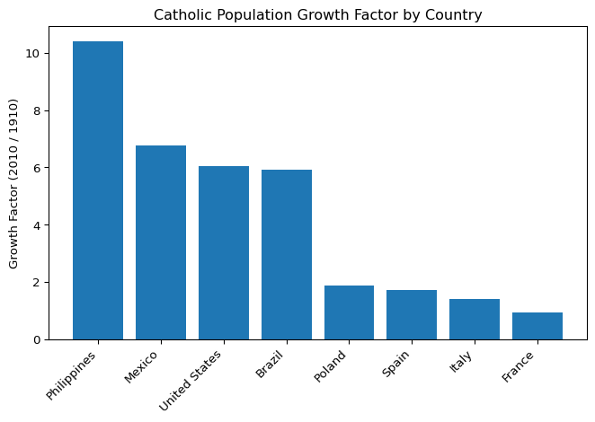

```python
import matplotlib.pyplot as plt

plt.figure()
plt.bar(df_merge["Country"], df_merge["GrowthFactor"])
plt.xticks(rotation=45, ha="right")
plt.ylabel("Growth Factor (2010 / 1910)")
plt.title("Catholic Population Growth Factor by Country")
plt.tight_layout()
```

## Now to pull historic info from each country

Here I used beautiful soup again to pull information from different wikipedia pages about the Catholic Church in those countries. I was hoping that it would provide unbiased information compared to a news source that might be biased politically or religiously. Additionally, they have a verification system that removes any misinformation pretty soon after posting, so this helped my reservations in using Wikipedia for the project.

```python
import requests
from bs4 import BeautifulSoup

countries = df_merge["Country"].tolist()

wiki_slugs = {
    "Philippines": "Catholic_Church_in_the_Philippines",
    "Mexico": "Catholic_Church_in_Mexico",
    "United States": "Catholic_Church_in_the_United_States",
    "Brazil": "Catholic_Church_in_Brazil",
    "Poland": "Catholic_Church_in_Poland",
    "Spain": "Catholic_Church_in_Spain",
    "Italy": "Catholic_Church_in_Italy",
    "France": "Catholic_Church_in_France",
}
```

Here I created a user-agent to access teh wikipedia pages to get past potential blockages. Then I downloaded the webpages and parsed through them to get the main text blocks. This block essentially defines the scraping logic and how to go about it.

```python
import requests
from bs4 import BeautifulSoup

headers = {
    "User-Agent": (
        "Mozilla/5.0 (Windows NT 10.0; Win64; x64) "
        "AppleWebKit/537.36 (KHTML, like Gecko) "
        "Chrome/120.0.0.0 Safari/537.36"
    )
}

def scrape_country_text(country):
    slug = wiki_slugs[country]
    url = f"https://en.wikipedia.org/wiki/{slug}"

    resp = requests.get(url, headers=headers)
    resp.raise_for_status()

    soup = BeautifulSoup(resp.text, "html.parser")

    content_div = soup.select_one("div.mw-parser-output")
    if content_div is None:
        return ""

    paragraphs = []

    for p in content_div.find_all("p", recursive=False):
        text = p.get_text(" ", strip=True)
        if text:
            paragraphs.append(text)

    if not paragraphs:
        for p in content_div.find_all("p"):
            text = p.get_text(" ", strip=True)
            if text:
                paragraphs.append(text)

    return " ".join(paragraphs)
```

Then I perform the actual scraping.

```python
rows = []

for country in countries:
    print(f"Scraping {country}...")
    try:
        text = scrape_country_text(country)
    except Exception as e:
        print(f"  Error scraping {country}: {e}")
        text = ""

    rows.append({"Country": country, "Text": text})

wiki_df = pd.DataFrame(rows)
print("Number of rows:", len(wiki_df))
display(wiki_df)
```

```
Scraping Philippines...
Scraping Mexico...
Scraping United States...
Scraping Brazil...
Scraping Poland...
Scraping Spain...
Scraping Italy...
Scraping France...
Number of rows: 8
```

|  | Country | Text |
| --- | --- | --- |
| 0 | Philippines | As part of the worldwide Catholic Church , the... |
| 1 | Mexico | The Mexican Catholic Church , or Catholic Chur... |
| 2 | United States | The Catholic Church in the United States is pa... |
| 3 | Brazil | The Brazilian Catholic Church , or Catholic Ch... |
| 4 | Poland | Polish members of the Catholic Church , like e... |
| 5 | Spain | The Spanish Catholic Church , or Catholic Chur... |
| 6 | Italy | The Italian Catholic Church , or Catholic Chur... |
| 7 | France | The Catholic Church in France , Gallican Churc... |

Now I’ll clean the text. I imported English_Stop_Words to get rid of common words that might accidentally get picked up. I also changed everything to all lowercase so it limits variation. Then I got rid of puncuation, numbers and special characters. Then I tokenized it to get it ready for topic modeling.

```python
import re
from sklearn.feature_extraction.text import ENGLISH_STOP_WORDS

def clean_text(t):
    if not isinstance(t, str):
        return ""
    t = t.lower()
    t = re.sub(r"[^a-z\s]", " ", t)
    tokens = t.split()
    tokens = [w for w in tokens if len(w) > 2 and w not in ENGLISH_STOP_WORDS]
    return " ".join(tokens)

wiki_df["Clean_Text"] = wiki_df["Text"].apply(clean_text)
wiki_df[["Country", "Clean_Text"]]
```

|  | Country | Clean_Text |
| --- | --- | --- |
| 0 | Philippines | worldwide catholic church catholic church phil... |
| 1 | Mexico | mexican catholic church catholic church mexico... |
| 2 | United States | catholic church united states worldwide latin ... |
| 3 | Brazil | brazilian catholic church catholic church braz... |
| 4 | Poland | polish members catholic church like world spir... |
| 5 | Spain | spanish catholic church catholic church spain ... |
| 6 | Italy | italian catholic church catholic church italy ... |
| 7 | France | catholic church france gallican church french ... |

# Topic Modeling

## Topic Modeling 1

Here I imported the necessary packages for vectorization. Then I split the countries into 2 different growth groups. Then I vectorized the text with various parameters. I ignored words that appeared in 95% of documents and words that appeared in only one document. This way it takes out super general words and allows for general themes to come through.

```python
from sklearn.feature_extraction.text import CountVectorizer
from sklearn.decomposition import LatentDirichletAllocation

high_growth = ["Philippines", "Mexico", "United States", "Brazil"]
low_growth  = ["France", "Italy", "Spain", "Poland"]

vectorizer = CountVectorizer(max_df=0.95, min_df=2)
X = vectorizer.fit_transform(wiki_df["Clean_Text"])

feature_names = vectorizer.get_feature_names_out()
```

Here I defined the amount of topics I wanted. Then i set up the LDA model. I told it to build 3 topics, and to have a random state of 42, making it partly random and reproducible. I also told it to use everything at once using batch.

```python
n_topics = 3

lda = LatentDirichletAllocation(
    n_components=n_topics,
    random_state=42,
    learning_method="batch"
)
lda.fit(X)
```

```
LatentDirichletAllocation(n_components=3, random_state=42)
```

Here I printed out the top words for each topic.

```python
def print_top_words(model, feature_names, n_top_words=10):
    for topic_idx, topic in enumerate(model.components_):
        top_indices = topic.argsort()[:-n_top_words - 1:-1]
        top_words = [feature_names[i] for i in top_indices]
        print(f"Topic #{topic_idx}: {' | '.join(top_words)}")

print_top_words(lda, feature_names, n_top_words=10)
```

```
Topic #0: population | brazil | identified | catholics | census | mexico | million | country | survey | national
Topic #1: rome | cathedral | saint | communion | dioceses | bishop | century | peter | city | catholics
Topic #2: spanish | population | largest | state | philippines | conference | united | world | states | period
```

### Topic Distribution

Here I showed the way that each topic was distributed among the countries. I was hoping to see some patterns among high growth and low growth. It appears that low growth countries really liked topic 1 (2), which the high growth countries really liked topics 0 and 2 (1&3)

```python
doc_topic_dist = lda.transform(X)

for i in range(n_topics):
    wiki_df[f"Topic_{i}_prob"] = doc_topic_dist[:, i]

wiki_df[["Country"] + [f"Topic_{i}_prob" for i in range(n_topics)]]
```

|  | Country | Topic_0_prob | Topic_1_prob | Topic_2_prob |
| --- | --- | --- | --- | --- |
| 0 | Philippines | 0.008866 | 0.008337 | 0.982797 |
| 1 | Mexico | 0.976034 | 0.010697 | 0.013269 |
| 2 | United States | 0.016021 | 0.015512 | 0.968467 |
| 3 | Brazil | 0.989767 | 0.005050 | 0.005183 |
| 4 | Poland | 0.985443 | 0.007306 | 0.007251 |
| 5 | Spain | 0.022123 | 0.022432 | 0.955445 |
| 6 | Italy | 0.007853 | 0.984196 | 0.007950 |
| 7 | France | 0.005545 | 0.989015 | 0.005440 |

Here I continued with that analysis and calculated average topic probabilities. This reinforced the same topic finding associations from above.

```python
wiki_df["Growth_Group"] = wiki_df["Country"].apply(
    lambda c: "High" if c in high_growth else "Low"
)

topic_cols = [f"Topic_{i}_prob" for i in range(n_topics)]

group_topics = wiki_df.groupby("Growth_Group")[topic_cols].mean()
group_topics
```

| Growth_Group | Topic_0_prob | Topic_1_prob | Topic_2_prob |
| --- | --- | --- | --- |
| High | 0.497672 | 0.009899 | 0.492429 |
| Low | 0.255241 | 0.500737 | 0.244022 |

## Topic Modeling 2

I wanted to try and continue to find patterns with topic modeling. So I did high growth key words versus low growth key words.

```python
from sklearn.feature_extraction.text import TfidfVectorizer
import pandas as pd
import numpy as np

wiki_df["Growth_Group"] = wiki_df["Country"].apply(
    lambda c: "High" if c in high_growth else "Low"
)

group_texts = wiki_df.groupby("Growth_Group")["Clean_Text"].apply(lambda x: " ".join(x))

vectorizer = TfidfVectorizer(max_features=2000)
tfidf_matrix = vectorizer.fit_transform(group_texts)

feature_names = np.array(vectorizer.get_feature_names_out())

tfidf_df = pd.DataFrame(
    tfidf_matrix.toarray(),
    index=group_texts.index,
    columns=feature_names
)

top_high = tfidf_df.loc["High"].sort_values(ascending=False).head(20)
top_low = tfidf_df.loc["Low"].sort_values(ascending=False).head(20)

print("Top High-Growth Keywords:\n", top_high)
print("\nTop Low-Growth Keywords:\n", top_low)
```

```
Top High-Growth Keywords:
 catholic       0.582849
church         0.376031
brazil         0.290674
population     0.244420
mexico         0.184975
brazilian      0.158550
largest        0.158550
identified     0.112809
philippines    0.105700
period         0.105700
faith          0.105700
country        0.094008
according      0.079275
philippine     0.079275
percent        0.079275
mexican        0.079275
census         0.075206
world          0.075206
pope           0.075206
million        0.075206
Name: High, dtype: float64

Top Low-Growth Keywords:
 church       0.490928
catholic     0.457071
france       0.190340
rome         0.186214
cathedral    0.166547
french       0.166547
italy        0.142755
italian      0.142755
poland       0.142755
saint        0.118962
pope         0.118500
catholics    0.101571
bishop       0.095170
dioceses     0.084643
countries    0.071377
city         0.071377
includes     0.071377
paris        0.071377
priestly     0.071377
baptized     0.071377
Name: Low, dtype: float64
```

### High growth topics versus Low Growth Topics.

It didn’t give much more insight.

```python
from sklearn.feature_extraction.text import CountVectorizer
from sklearn.decomposition import LatentDirichletAllocation

def lda_for_group(group_name):
    texts = wiki_df[wiki_df["Growth_Group"] == group_name]["Clean_Text"].tolist()
    vectorizer = CountVectorizer(max_df=0.95, min_df=1)
    X = vectorizer.fit_transform(texts)
    lda = LatentDirichletAllocation(n_components=2, random_state=42)
    lda.fit(X)
    return lda, vectorizer.get_feature_names_out()

def print_topics(model, feature_names, n_top=12):
    for idx, topic in enumerate(model.components_):
        top_indices = topic.argsort()[:-n_top - 1:-1]
        words = [feature_names[i] for i in top_indices]
        print(f"Topic #{idx}: {' | '.join(words)}\n")

lda_high, feat_high = lda_for_group("High")
print("\n=== HIGH-GROWTH TOPICS ===")
print_topics(lda_high, feat_high)

lda_low, feat_low = lda_for_group("Low")
print("\n=== LOW-GROWTH TOPICS ===")
print_topics(lda_low, feat_low)
```

```
=== HIGH-GROWTH TOPICS ===
Topic #0: largest | faith | philippines | world | philippine | united | states | spanish | catholicism | conference | period | state

Topic #1: brazil | identified | brazilian | mexico | census | million | catholics | national | according | mexican | percent | bishops


=== LOW-GROWTH TOPICS ===
Topic #0: poland | spanish | catholics | includes | conference | baptized | population | catholicism | countries | state | survey | comprise

Topic #1: france | french | cathedral | italy | italian | saint | dioceses | communion | bishop | priestly | paris | century
```

## Topic modeling (attempt 3:(stricter))

I had felt like The words from the first rounds of topic modeling above weren’t very helpful. So I redid it with many stopwords that somewhat helped to bring forth more unique and characteristic words. I was really just hoping to bring about stronger insights. I also narrowed it down to just 2 topics in hopes of having a clearer distinction between the themes that emerge. I realized I accidentally deleted a crucial code block with the “clean text” column so I added it back in here, before going through with the new topic modeling.

```python
import re
from sklearn.feature_extraction.text import ENGLISH_STOP_WORDS

def clean_text(t):
    if not isinstance(t, str):
        return ""
    t = t.lower()
    t = re.sub(r"[^a-z\s]", " ", t)
    tokens = t.split()
    tokens = [w for w in tokens if len(w) > 2 and w not in ENGLISH_STOP_WORDS]
    return " ".join(tokens)

wiki_df["Clean_Text"] = wiki_df["Text"].apply(clean_text)
```

new topic modeling method

```python
from sklearn.feature_extraction.text import CountVectorizer, ENGLISH_STOP_WORDS
from sklearn.decomposition import LatentDirichletAllocation


extra_stopwords = {
    "population", "brazil", "mexico", "spanish", "philippines", "religious", "approximately",
    "united", "states", "catholics", "largest", "country", "church", "catholic",
    "census", "million", "survey", "national",
    "rome", "cathedral", "dioceses", "bishop",
    "century", "peter", "city", "conference",
    "world", "state", "period", "identified",
    "christian", "catholicism", "members", "number", "data", "worldwide", "countries",
    "according", "bishops", "statistics", "spiritual", "leadership", "holy", "previous", "estimated", "having", "communion", "latin", "second", "episcopal", "society", "includes", "year", "beginning", "early", "established", "served",
    "nations", "primate", "eparchies", "surveyed", "adherents"}

custom_stop = list(ENGLISH_STOP_WORDS.union(extra_stopwords))

vectorizer = CountVectorizer(
    max_df=0.95,
    min_df=2,
    stop_words=custom_stop,
    ngram_range=(1, 2)
)

X = vectorizer.fit_transform(wiki_df["Clean_Text"])
feature_names = vectorizer.get_feature_names_out()

n_topics = 2

lda = LatentDirichletAllocation(
    n_components=n_topics,
    random_state=42,
    learning_method="batch"
)
lda.fit(X)

def print_top_words(model, feature_names, n_top_words=10):
    for topic_idx, topic in enumerate(model.components_):
        top_indices = topic.argsort()[:-n_top_words - 1:-1]
        top_words = [feature_names[i] for i in top_indices]
        print(f"Topic #{topic_idx}: {' | '.join(top_words)}")

print_top_words(lda, feature_names, n_top_words=10)
```

```
Topic #0: percent | religion | christianity | baptized | roman | jurisdictions | eastern | practiced | archbishop | mass
Topic #1: saint | official | vatican | empire | roman | roman empire | saints | including | pilgrimage | paul
```

### Topic Distribution

Here I ran the topic distribution again to see how it may have been affected by the stop words.

```python
doc_topic_dist = lda.transform(X)

for i in range(n_topics):
    wiki_df[f"Topic_{i}_prob"] = doc_topic_dist[:, i]

wiki_df[["Country"] + [f"Topic_{i}_prob" for i in range(n_topics)]]
```

|  | Country | Topic_0_prob | Topic_1_prob |
| --- | --- | --- | --- |
| 0 | Philippines | 0.888282 | 0.111718 |
| 1 | Mexico | 0.944775 | 0.055225 |
| 2 | United States | 0.747917 | 0.252083 |
| 3 | Brazil | 0.085807 | 0.914193 |
| 4 | Poland | 0.941373 | 0.058627 |
| 5 | Spain | 0.500000 | 0.500000 |
| 6 | Italy | 0.035767 | 0.964233 |
| 7 | France | 0.028431 | 0.971569 |

Here I split it into high growth and low growth again. I found that topic 0 is more heavily leaned into by the high growth group. While the low growth group more heavily leans into Topic 1. It seems as if topic 0 has themes of evangelization, while topic 1 has themes of historical influence. Which would correlate with findings of growth vs decay.

```python
wiki_df["Growth_Group"] = wiki_df["Country"].apply(
    lambda c: "High" if c in high_growth else "Low"
)

topic_cols = [f"Topic_{i}_prob" for i in range(n_topics)]

group_topics = wiki_df.groupby("Growth_Group")[topic_cols].mean()
group_topics
```

| Growth_Group | Topic_0_prob | Topic_1_prob |
| --- | --- | --- |
| High | 0.666695 | 0.333305 |
| Low | 0.376393 | 0.623607 |

# Sentiment Analysis

## Sentiment Analysis Score per country (1)

Next I was curious to do a sentiment analysis, because why not? Actually I was curious if certain words in alignment with growth versus decay might show up here. I created positive and negative sets of words.

```python
positive_words = {
    "growth", "expansion", "revival", "mission", "missions",
    "evangelization", "conversion", "conversions", "renewal",
    "recognition", "rights", "freedom", "liberty"
}

negative_words = {
    "decline", "secularization", "persecution", "persecutions",
    "repression", "scandal", "scandals", "crisis", "crises",
    "conflict", "war", "wars", "suppression", "anti", "hostility"
}
```

Then I did the actual analysis. I split the text into individual token words, separately counted how many were in the positive and negative lists, and then created a score between -1 and 1. Unfortunately, only negative words got picked up on. So there wasn’t much insight here.

```python
def simple_sentiment_score(text):
    if not isinstance(text, str):
        return 0.0
    tokens = text.split()
    if not tokens:
        return 0.0

    pos = sum(1 for t in tokens if t in positive_words)
    neg = sum(1 for t in tokens if t in negative_words)

    return (pos - neg) / len(tokens)

wiki_df["Sentiment_Score"] = wiki_df["Clean_Text"].apply(simple_sentiment_score)

wiki_df[["Country", "Sentiment_Score"]]
```

|  | Country | Sentiment_Score |
| --- | --- | --- |
| 0 | Philippines | 0.000000 |
| 1 | Mexico | 0.000000 |
| 2 | United States | 0.000000 |
| 3 | Brazil | 0.000000 |
| 4 | Poland | -0.008696 |
| 5 | Spain | 0.000000 |
| 6 | Italy | 0.000000 |
| 7 | France | -0.007463 |

I split the sentiment score by growth group, but it didn’t really give anymore information.

```python
sent_group = wiki_df.groupby("Growth_Group")["Sentiment_Score"].mean()
sent_group
```

```
Growth_Group
High    0.00000
Low    -0.00404
Name: Sentiment_Score, dtype: float64
```

Next I made a bar chart showing the sentiment analysis.

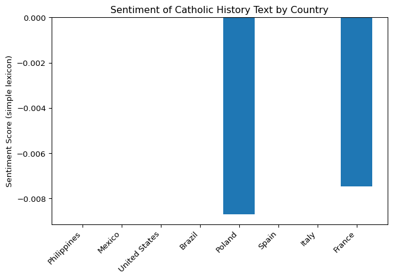

```python
plt.figure()
plt.bar(wiki_df["Country"], wiki_df["Sentiment_Score"])
plt.xticks(rotation=45, ha="right")
plt.ylabel("Sentiment Score (simple lexicon)")
plt.title("Sentiment of Catholic History Text by Country")
plt.tight_layout()
```

## Attempting supervised machine learning sentiment analysis (2)

I wanted to try a different form of sentiment analysis without my own chosen words. Here I used regex to break the wikipedia pages down by sentences.

```python
def split_into_sentences(text):
    import re
    if not isinstance(text, str):
        return []
    text = re.sub(r'([.!?])', r'\1 ', text)
    sentences = re.split(r'(?<=[.!?])\s+', text)
    return [s.strip() for s in sentences if s.strip()]
```

Next i went through each countries Wikipedia pages and collected the sentences into a list. I also made sure to only get sentences longer than 6 words in order to avoid fragments and titles.

```python
all_sentences = []

for text in wiki_df["Text"]:
    for s in split_into_sentences(text):
        if len(s.split()) > 6:
            all_sentences.append(s)
```

Here I imported a set of randomly shuffled sentences that I will later manually label.

```python
import random

random.shuffle(all_sentences)
sample_sentences = all_sentences[:120]
```

Here I created a data frame that will allow me to store their sentiment labels.

```python
import pandas as pd

df_label = pd.DataFrame({
    "sentence": sample_sentences,
    "label": [""] * len(sample_sentences)
})

df_label.head(10)
```

|  | sentence | label |
| --- | --- | --- |
| 0 | [ 7 ] 80 to 90 priests are ordained every year... |  |
| 1 | In many parts of the country, Catholic Christi... |  |
| 2 | One of the challenges faced by the Catholic Ch... |  |
| 3 | [ 1 ] The ordinaries of these jurisdictions co... |  |
| 4 | [ 1 ] These figures made Brazil the single cou... |  |
| 5 | 3% of the population identified themselves as ... |  |
| 6 | [ 13 ] Some of the most famous French saints a... |  |
| 7 | [ 5 ] In 2015, the church recorded that 97. |  |
| 8 | During the same period, Protestants increased ... |  |
| 9 | 4 percentage points from 2010, when 65. |  |

Next I exported the the table into a CSV file.

```python
df_label.to_csv("labeling_sentences.csv", index=False)
```

```python
df_label = pd.read_csv("labeling_sentences1.csv")
df_label
```

|  | sentence | label |
| --- | --- | --- |
| 0 | The Brazilian Catholic Church , or Catholic Ch... | positive |
| 1 | The pope resides in Vatican City, enclaved in ... | neutral |
| 2 | Peter , Institute of Christ the King Sovereign... | negative |
| 3 | Having been a major centre for Christian pilgr... | positive |
| 4 | The status of the Catholic Church as the sole ... | positive |
| ... | ... | ... |
| 77 | In 496 Remigius baptized King Clovis I , who t... | positive |
| 78 | Its national shrine , Lourdes , is visited by ... | positive |
| 79 | Established in the second century in unbroken ... | positive |
| 80 | 3% of the population identified themselves as ... | negative |
| 81 | Mark 's in Venice , and Brunelleschi 's Floren... | neutral |

82 rows × 2 columns

Here I dropped rows with neutral labels. Then I counted how many rows are positive or negative.

```python
df_label = df_label[df_label["label"] != "neutral"].reset_index(drop=True)
df_label["label"].value_counts()
```

```
label
positive    31
negative    15
Name: count, dtype: int64
```

Here I imported the Machine Learning packages I would need to create the pipeline.

```python
from sklearn.model_selection import train_test_split
from sklearn.feature_extraction.text import TfidfVectorizer
from sklearn.linear_model import LogisticRegression
from sklearn.metrics import classification_report, accuracy_score
import pandas as pd
```

Here I defined my training data(75%) and testing data(25%). I also stratified it to make sure that there was a fair representation of labels among the data.

```python
X_train, X_test, y_train, y_test = train_test_split(
    df_label["sentence"],
    df_label["label"],
    test_size=0.25,
    random_state=42,
    stratify=df_label["label"]
)
```

Next I vectorized the data by converting the sentences to numeric features that captured the importance of the words. I integrated stop words and limited the vocabulary to 5000.

```python
tfidf = TfidfVectorizer(
    stop_words="english",
    max_features=5000,
    ngram_range=(1,2)
)

X_train_vec = tfidf.fit_transform(X_train)
X_test_vec = tfidf.transform(X_test)
```

Here I ran the logistic regression. I kept the max iteration to 300 to give it enough to converge but not too much to make it take forever.

```python
clf = LogisticRegression(max_iter=300)
clf.fit(X_train_vec, y_train)
```

```
LogisticRegression(max_iter=300)
```

Next I evaluated the performance of the model. I got an acuracy of .67, but also a precision score of 0.00 for negative sentiments becasue it labeled all negative sentences incorrectly. This is probably due to the training set being so small.

```python
y_pred = clf.predict(X_test_vec)

print("Accuracy:", accuracy_score(y_test, y_pred))
print(classification_report(y_test, y_pred))
```

```
Accuracy: 0.6666666666666666
              precision    recall  f1-score   support

    negative       0.00      0.00      0.00         4
    positive       0.67      1.00      0.80         8

    accuracy                           0.67        12
   macro avg       0.33      0.50      0.40        12
weighted avg       0.44      0.67      0.53        12
```

This is the last step where I used the model on each country’s wikipedia page. I turned each whole text into a TF-IDF vector using the same vocabulary. Then I gave probabilities to each class of pos or neg. Next I extracted those probabilities to create the sentiment analysis score and finally gave a hard label to the sentiment score. The logistic regression model results point to all pages having a positive sentiment score. The highest growth country did have the highest sentiment score which was a positive. However there was no clear distinction of sentiment among high growth and low growth groups.

```python
wiki_vec = tfidf.transform(wiki_df["Text"])
probs = clf.predict_proba(wiki_vec)

wiki_df["ML_Sentiment_Score"] = probs[:, list(clf.classes_).index("positive")]
wiki_df["ML_Sentiment_Label"] = clf.predict(wiki_vec)

wiki_df[["Country", "ML_Sentiment_Score", "ML_Sentiment_Label"]]
```

|  | Country | ML_Sentiment_Score | ML_Sentiment_Label |
| --- | --- | --- | --- |
| 0 | Philippines | 0.801810 | positive |
| 1 | Mexico | 0.699601 | positive |
| 2 | United States | 0.771709 | positive |
| 3 | Brazil | 0.695276 | positive |
| 4 | Poland | 0.681315 | positive |
| 5 | Spain | 0.775712 | positive |
| 6 | Italy | 0.726184 | positive |
| 7 | France | 0.689739 | positive |

# Regex content extraction

I wanted to keep trying to see if I could find more details that would help me solve the question. This time I used regex mthods to get the dates during the time period of 1910-2010.

```python
import re

def extract_events_1910_2010(text):
    if not isinstance(text, str):
        return []

    year_regex = r"(19[1-9]\d|200\d|2010)"
    pattern = year_regex + r".{0,80}"

    matches = re.findall(pattern, text)

    return matches
```

Only 4 countries had dates show up.

```python
wiki_df["Events_1910_2010"] = wiki_df["Text"].apply(extract_events_1910_2010)
wiki_df[["Country", "Events_1910_2010"]]
```

|  | Country | Events_1910_2010 |
| --- | --- | --- |
| 0 | Philippines | [] |
| 1 | Mexico | [] |
| 2 | United States | [] |
| 3 | Brazil | [2010, 1991] |
| 4 | Poland | [2000] |
| 5 | Spain | [1978, 1976, 1953] |
| 6 | Italy | [1985] |
| 7 | France | [] |

Then I picked out the sentences surrounding those years to see what further details might appear. The results here aren’t super insightful. The only one that really sticks out to me is how in the year 2000 Poland had baptized 99% of all children born.

```python
def extract_events_1910_2010_structured(text):
    if not isinstance(text, str):
        return []

    pattern = r"(19[1-9]\d|200\d|2010)(.{0,80})"
    results = []

    for match in re.findall(pattern, text):
        year = match[0]
        context = match[1].strip()
        results.append((int(year), context))

    return results

wiki_df["Events_1910_2010_structured"] = wiki_df["Text"].apply(extract_events_1910_2010_structured)
wiki_df[["Country", "Events_1910_2010_structured"]]
```

|  | Country | Events_1910_2010_structured |
| --- | --- | --- |
| 0 | Philippines | [] |
| 1 | Mexico | [] |
| 2 | United States | [] |
| 3 | Brazil | [(2010, , when 65.1% of the population aged 10... |
| 4 | Poland | [(2000, s, 99% of all children born in Poland ... |
| 5 | Spain | [(1978, establishes the non-denominationality ... |
| 6 | Italy | [(1985, , with the renegotiation of the Latera... |
| 7 | France | [] |

# Conclusion

My original question was trying to understand why different country’s Catholic populations grew exponentially while others diminished. I went through a long series of Unstructured Analytic methods in order to find the answer.

First I started by scraping the Pew research center for 2 images that detailed statistics from 1910 to 2010. From there I used Optical Character Recognition to try and scrape the information from the images. I would have just scraped the words from the article itself, however the data was only contained in the images. Which led to a fun unstructured problem of downloading and using the Tesseract, which made me feel like I was in a Marvel Avengers movie. OCR made a few mistakes which I corrected and then I computed the growth factor and percent change. The Phillipines had the greatest then following in order was Mexico, the US, Brazil, Poland, Spain, Italy, and France. It was quite interesting because France had the largest Catholic population in 1910 but then “fell from the graces” of country population growth lol.

I had been hoping that the sentiment analysis might find overwhelmingly negative and positive words with a greater divide. Unfortunately Wikipedia pages contain pretty neutral text so most of the analysis was pretty balancced among high and low growth. The last method of regex content extraction was used in hopes that there might be a stark historical event that may have had a large impact on these population numbers. Unfortunately that wasn’t much of the case either.

All in all, this project was a test of patience and perserverence with little to show for it. I wish I had better results, but it was a fun process exploring ideas from class in the context of global Catholic history.